# Reproducible Research: Peer Assessment 1

## Introduction

It is now possible to collect a large amount of data about personal movement using activity monitoring devices such as a [Fitbit](http://www.fitbit.com), [Nike Fuelband](http://www.nike.com/us/en_us/c/nikeplus-fuelband), or [Jawbone Up](https://jawbone.com/up). These type of devices are part of the “quantified self” movement – a group of enthusiasts who take measurements about themselves regularly to improve their health, to find patterns in their behavior, or because they are tech geeks. But these data remain under-utilized both because the raw data are hard to obtain and there is a lack of statistical methods and software for processing and interpreting the data.

This assignment makes use of data from a personal activity monitoring device. This device collects data at 5 minute intervals through out the day. The data consists of two months of data from an anonymous individual collected during the months of October and November, 2012 and include the number of steps taken in 5 minute intervals each day. Our report will be answering questions based on the insight provided by this data.

## Loading and preprocessing the data

Data was loaded directly from a zipped CSV file:

```r
# Setting right folder
setwd("~/GitHub/RepData_PeerAssessment1")
#Reading data
activity_data <- read.csv(unz("activity.zip", "activity.csv"))
#Converting Date from strings to date format
activity_data$date <- as.Date(activity_data$date,"%Y-%m-%d")
```

## What is mean total number of steps taken per day?

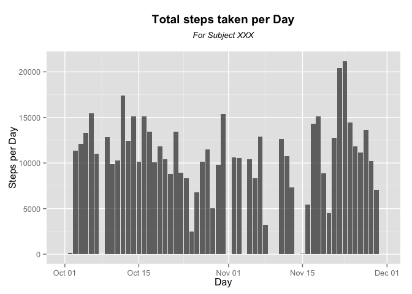

```r
library(dplyr)
library(ggplot2)
#Grouping intervals by date
dates.g <- group_by(activity_data, date)
# Summarizing steps by day
steps_per_day.df <- summarize(dates.g, steps_per_day = sum(steps, na.rm = TRUE))
# Creating Graph
## Setup ggplot with data frame
g <- ggplot(steps_per_day.df, aes(x = date, y = steps_per_day))
g + geom_bar(alpha = 7/10, stat = "identity") +
    labs(x = "Day") +
    labs(y = "Steps per Day") +
    labs(title = expression(atop(bold("Total steps taken per Day"), atop(italic("For Subject XXX"), ""))))
```

```r
# Calculate and report the mean and median total number of steps taken per day
# Mean steps per day
avg_steps_day <- mean(steps_per_day.df$steps_per_day)
# Median steps per day
median_steps_per_day <- median(steps_per_day.df$steps_per_day)
```

The mean of steps taken per day is **9,354.23**, while the median of the steps taken per day was **10,395** steps.

## What is the average daily activity pattern?

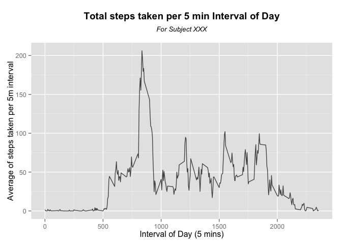

```r
#Grouping records by interval
intervals.g <- group_by(activity_data, interval)
# Summarizing steps by day
steps_per_interval.df <- summarize(intervals.g, steps_per_interval = mean(steps, na.rm = TRUE))

# Creating Graph
## Setup ggplot with data frame
g <- ggplot(steps_per_interval.df, aes(x = interval, y = steps_per_interval))
g + geom_line(alpha = 7/10, color = "black", stat = "identity") +
    labs(x = "Interval of Day (5 mins)") +
    labs(y = "Average of steps taken per 5m interval") +
    labs(title = expression(atop(bold("Total steps taken per 5 min Interval of Day"), atop(italic("For Subject XXX"), ""))))
```

```r
# Interval with most steps
most_steps_interval_idx <- which.max(steps_per_interval.df$steps_per_interval)
most_steps_interval_lbl <- steps_per_interval.df$interval[most_steps_interval_idx]
```

The interval with most steps, in average, is the **104th** interval, which corresponds to the interval starting at **835hrs**. As can be appreciated in the previous graph, activity starts shortly before 6AM, and cycles through day, reducing to a minimum after 7PM. The activity peak occurs early in the day, between 8AM and 9AM.

## Imputing missing values

There are some intervals with missing step data. Observing the data, I may say that in some days, data has not been gathered at all.

```r
# Calculating intervals with no data (NA)
na_intervals <- sum(is.na(activity_data$steps))
```

Those intervals without step data are **2304**.

We will be imputing the missing step data with the average of the steps taken on the same interval for the days where data is available. Then we will be able to determine how this modifies the total of steps taken per day.

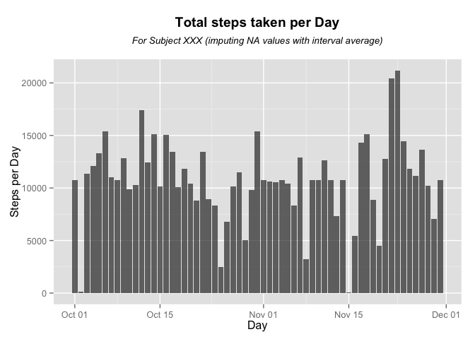

```r
# Create a new dataset that is equal to the original dataset but with
# the missing data filled in.

# Making a copy of the original file
activity_data.imp <- left_join(activity_data, steps_per_interval.df) #Copy of df to be populated with imputed values
#activity_data.imp$steps2 <- activity_data.imp$steps
activity_data.imp$steps[is.na(activity_data.imp$steps)] <- activity_data.imp$steps_per_interval
activity_data.imp <- select(activity_data.imp, 1:3)

# Make a histogram of the total number of steps taken each day and
# Calculate and report the mean and median total number of steps
# taken per day. Do these values differ from the estimates from the
# first part of the assignment?

#Grouping intervals by date
dates.imp.g <- group_by(activity_data.imp, date)
# Summarizing steps by day
steps_per_day.imp.df <- summarize(dates.imp.g, steps_per_day = sum(steps, na.rm = TRUE))

# Creating Graph
## Setup ggplot with data frame
g <- ggplot(steps_per_day.imp.df, aes(x = date, y = steps_per_day))
g + geom_bar(alpha = 7/10, stat = "identity") +
    labs(x = "Day") +
    labs(y = "Steps per Day") +
    labs(title = expression(atop(bold("Total steps taken per Day"), atop(italic("For Subject XXX (imputing NA values with interval average)"), ""))))
```

```r
# Calculate and report the mean and median total number of steps taken per day
# Mean steps per day
avg_steps_day.imp <- mean(steps_per_day.imp.df$steps_per_day)
# Median steps per day
median_steps_day.imp <- median(steps_per_day.imp.df$steps_per_day)
```

The mean of total steps taken per day after imputing is **10,766.19** and the median of the total steps per day is **10,766.19**. Compared to the previously obtained values (9,354.23 and 10,395 as mean and median values), the values obtained after imputing the missing values are somewhat larger.

Let’s explore the impact of imputing the missing values using the average of the available data, by looking at both histograms side by side.

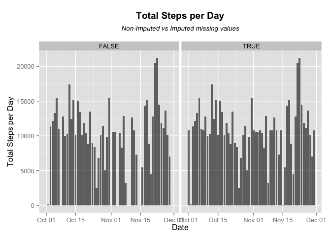

```r
# What is the impact of imputing missing data on the estimates of
# the total daily number of steps?

# New table with day totals for steps, non imputed and imputed
comparedata <- steps_per_day.df
comparedata$imputed <- FALSE
comparedata <- bind_rows(comparedata, steps_per_day.imp.df)
comparedata$imputed[is.na(comparedata$imputed)] <- TRUE

# Drawing Histogram
g <- ggplot(comparedata, aes(x = date, y = steps_per_day))
g + geom_bar(alpha = 7/10, stat = "identity") +
    facet_grid(. ~ imputed) +
    labs(x = "Date") +
    labs(y = expression("Total Steps per Day")) +
    labs(title = expression(atop(bold("Total Steps per Day"), atop(italic("Non-Imputed vs Imputed missing values"), ""))))
```

As we are imputing missing data with the average of existing data, daily averages won’t go lower or higher, but the days that have no data at all, are pushed towards an “average day”. That is why some gaps present in the left histogram (the one with no imputed data) are filled in the graph presented to the right (which, of course, includes the imputed average data).

## Are there differences in activity patterns between weekdays and weekends?

We may answer this question by identifying each reacord with an indicator saying if its information regarding a weekday or a weekend day. By grouping the data of the interval averages, first by our weekday/weekend indicator and then by interval, then, we will be able to summarize by interval, providing the average of steps per 5 mins interval through a whole day, differentiating the weekdays from the weekends.

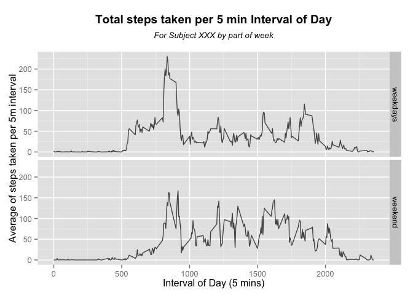

```r
# Create a new factor variable in the dataset with two
# levels – “weekday” and “weekend” indicating whether a given date is
# a weekday or weekend day.

# Weekdays will be flagged FALSE (0) and weekends will be TRUE (1)
activity_data.imp$weekpart <- !is.element(weekdays(activity_data.imp$date), c("Monday", "Tuesday", "Wednesday", "Thursday", "Friday"))
activity_data.imp$weekpart <- factor(activity_data.imp$weekpart, labels = c("weekdays", "weekend"))

#Grouping by interval
intervals.w.g <- group_by(activity_data.imp, weekpart, interval)
# Summarizing steps by day
steps_per_interval.w.df <- summarize(intervals.w.g, steps_per_interval = mean(steps, na.rm = TRUE))

# Creating Graph
## Setup ggplot with data frame
g <- ggplot(steps_per_interval.w.df, aes(x = interval, y = steps_per_interval))
g + geom_line(alpha = 7/10, color = "black", stat = "identity") +
    facet_grid(weekpart ~ .) +
    labs(x = "Interval of Day (5 mins)") +
    labs(y = "Average of steps taken per 5m interval") +
    labs(title = expression(atop(bold("Total steps taken per 5 min Interval of Day"), atop(italic("For Subject XXX by part of week"), ""))))
```

The conclusion at which we may arrive is that the activity peak which was previously identified happening in the early morning, is less accentuated on weekends, while the contrary happens on the rest of the day activity, appearing the subject to be more active through the day on weekends. Other notable observations would be regarding the time at which the subject activity starts and ends, appearing to be earlier on weekdays than in weekends.